# Module 2 — Differential Expression with limma

RNA-seq Tutorial: Linear Models, Contrasts, Empirical Bayes and Paired Designs, Step by Step

Francesco Cecere** · *Senior Bioinformatic Researcher* · AORN Santobono-Pausilipon IRCCS

05 novembre 2026

# From Module 1

Module 1 built one matrix of log2(TPM + 1) for 6 Wilms tumors and the 6 normal kidneys of the same children, and showed that tumor vs normal dominates the data. This module asks, gene by gene, **which genes change in the tumor**, and explains each step of **limma** along the way.

**Plan:** the linear model → design matrix → contrast → fitting → empirical Bayes moderation → reading the results → **adding the patient: the paired model** → testing a fold-change threshold (`treat`) → visualizing single genes.

```r
# Same import, matching and filtering as Module 1.
tumor_tpm   <- read_csv("data/TARGET_WT_gene_expression_tpm.csv", show_col_types = FALSE)
control_tpm <- read_csv("data/TARGET_WT_control_gene_expression_tpm.csv", show_col_types = FALSE)
tumor_metadata   <- read_csv("data/sample_metadata.csv", show_col_types = FALSE)
control_metadata <- read_csv("data/TARGET_WT_control_clinical_raw.csv", show_col_types = FALSE)

stopifnot(identical(tumor_tpm$gene_name, control_tpm$gene_name))
tpm <- as.matrix(bind_cols(tumor_tpm[, -1], control_tpm[, -1]))
rownames(tpm) <- tumor_tpm$gene_name

samples <- bind_rows(
  tumor_metadata %>% transmute(sample_id = case_submitter_id, patient = case_submitter_id, condition = "Tumor"),
  control_metadata %>% transmute(sample_id = sample_submitter_id, patient = case_submitter_id, condition = "Normal")
) %>%
  mutate(condition = factor(condition, levels = c("Normal", "Tumor")), patient = factor(patient))
samples <- samples[match(colnames(tpm), samples$sample_id), ]
stopifnot(identical(samples$sample_id, colnames(tpm)))

keep     <- rowSums(tpm >= 1) >= min(table(samples$condition))
log_expr <- log2(tpm[keep, ] + 1)

condition_colors <- c(Normal = "#7f8c8d", Tumor = "#8e44ad")
```

# Part 1 — One Linear Model per Gene

limma fits, **separately for every gene** $g$, a linear model of its log expression in sample $j$:

$$y_{gj} = \mathbf{x}_j^\top \boldsymbol{\beta}_g + \varepsilon_{gj},
\qquad \varepsilon_{gj} \sim N(0, \sigma_g^2)$$

- $\mathbf{x}_j$ describes sample $j$ (its condition, later also its patient): one row of the **design matrix**, the same for every gene.
- $\boldsymbol{\beta}_g$ are the gene’s **coefficients**, e.g. its mean log expression in normal kidney and in tumor.
- $\sigma_g^2$ is the gene’s residual **variance**: how much samples differ beyond what the model explains.

A comparison is then a question about the coefficients: “is $\beta_{\text{Tumor}} - \beta_{\text{Normal}} = 0$?”. The two ideas that make limma powerful are (1) that design and contrasts can describe **any** experiment, and (2) the **empirical Bayes** step of Part 5.

**limma-trend vs voom.** limma has two ways to handle RNA-seq. **voom** starts from raw **counts** and computes a precision weight for every observation. **limma-trend** starts from log-expression values and lets the prior variance depend on the gene’s average expression (Part 5). With raw counts, voom is preferred; with **TPM**, where counts are no longer available, **limma-trend** is the right choice, and it is what we use here.

# Part 2 — The Design Matrix

We start with the simplest model, which ignores the patients: `~ 0 + condition`. The design matrix has one row per sample and one column per coefficient; with `0 +` (“no intercept”) each column is a condition, and each coefficient is simply **that condition’s mean**.

```r
design <- model.matrix(~ 0 + condition, data = samples)
colnames(design) <- levels(samples$condition)
```

The design matrix: 1 marks each sample’s condition.

| sample | Normal | Tumor |
| --- | --- | --- |
| TARGET-50-PALKCW | 0 | 1 |
| TARGET-50-PAJNSL | 0 | 1 |
| TARGET-50-CAAAAR | 0 | 1 |
| TARGET-50-PAJPHA | 0 | 1 |
| TARGET-50-PAJNRL | 0 | 1 |
| TARGET-50-CAAAAQ | 0 | 1 |
| TARGET-50-PALKCW-11A | 1 | 0 |
| TARGET-50-PAJNSL-11A | 1 | 0 |
| TARGET-50-CAAAAQ-11A | 1 | 0 |
| TARGET-50-PAJPHA-11A | 1 | 0 |
| TARGET-50-PAJNRL-11A | 1 | 0 |
| TARGET-50-CAAAAR-11A | 1 | 0 |

**The alternative: `~ condition` (with intercept).** Then the first column is the *reference* (Normal) and the second is the **difference** Tumor − Normal. Both parameterizations fit exactly the same model and give identical results; `~ 0 + condition` is easier to read, and the comparison is written explicitly as a contrast.

# Part 3 — The Contrast: Writing Down the Question

A **contrast** is a combination of coefficients that equals zero if there is no effect. Here there is one question, tumor vs normal:

```r
contrast_matrix <- makeContrasts(Tumor_vs_Normal = Tumor - Normal, levels = design)
```

Contrast matrix: one column per question, one row per coefficient.

|  | Tumor_vs_Normal |
| --- | --- |
| Normal | -1 |
| Tumor | 1 |

With more groups the same mechanism expresses any question: `B - A`, `C - A`, `(B + C) / 2 - A` (the average of two groups vs a third), `(C - A) - (B - A)` (an interaction)…

# Part 4 — Fitting the Model

`lmFit()` estimates the coefficients and residual variance of every gene; `contrasts.fit()` turns the coefficients into the contrast.

```r
fit  <- lmFit(log_expr, design)
fit2 <- contrasts.fit(fit, contrast_matrix)
```

The coefficients really are condition means. For `UMOD`, a gene of mature kidney tubules:

UMOD: mean log2(TPM + 1) per condition, by hand and from lmFit.

| condition | mean_computed_by_hand | coefficient_from_lmFit |
| --- | --- | --- |
| Normal | 12.464 | 12.464 |
| Tumor | 0.030 | 0.030 |

UMOD is about 12 log2 units lower in the tumors, i.e. roughly 5,535-fold: the tumors have lost the mature kidney tubule.

# Part 5 — Empirical Bayes: Borrowing Strength Across Genes

To test a contrast we divide it by its standard error, which depends on the gene’s variance $s_g^2$. With **6 samples per group**, $s_g^2$ is very **unstable**: by chance some genes get a tiny variance and a huge, misleading t-statistic. limma assumes that the variances of all genes come from a common distribution, estimates that distribution **from all genes together**, and uses it to stabilize each gene’s estimate:

$$\tilde{s}_g^2 = \frac{d_0 \, s_0^2 + d_g \, s_g^2}{d_0 + d_g}$$

- $s_g^2$ with $d_g$ degrees of freedom: the gene’s own variance (here $d_g$ = 10: 12 samples − 2 coefficients).
- $s_0^2$ with $d_0$ “prior” degrees of freedom: the typical variance of all genes, estimated from the data.
- $\tilde{s}_g^2$: the **moderated** variance, a weighted average that pulls each gene toward the typical value. The **moderated t-statistic** uses $\tilde{s}_g$ instead of $s_g$, with $d_0 + d_g$ degrees of freedom.

```r
# trend = TRUE: the prior variance s0^2 depends on the gene's mean expression (limma-trend).
# robust = TRUE: genes with extreme variances are not allowed to distort the prior.
fit2 <- eBayes(fit2, trend = TRUE, robust = TRUE)
```

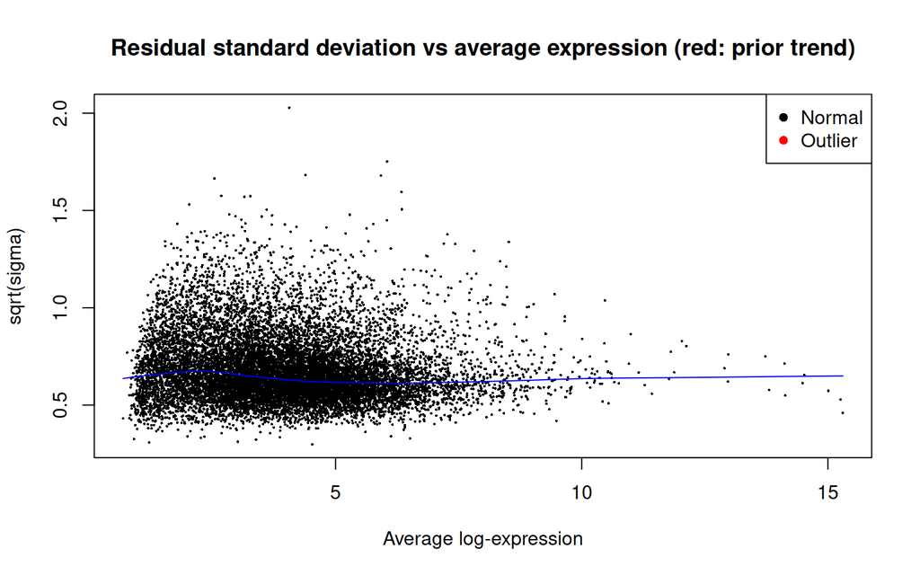

What moderation does, gene by gene: genes with an unusually small variance (left of the plot below) get it pulled up, those with an unusually large one get it pulled down.

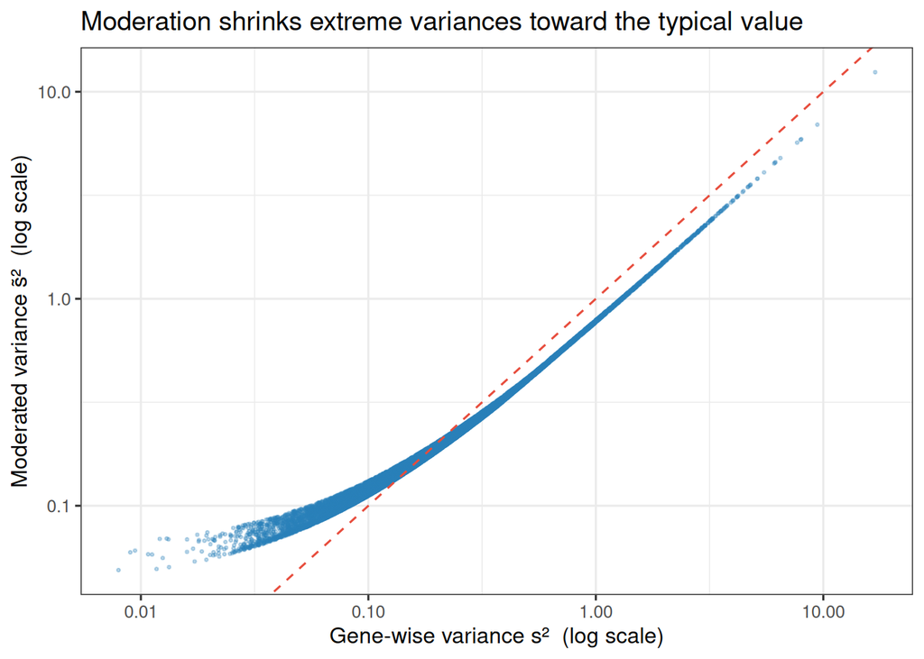

The practical effect: the moderated t-test finds more genes than a gene-by-gene t-test, and fewer of them are flukes of a tiny variance.

```r
ordinary_t <- fit2$coefficients[, 1] / (fit2$stdev.unscaled[, 1] * fit2$sigma)
ordinary_p <- 2 * pt(-abs(ordinary_t), df = fit2$df.residual)
```

Same data, same model: borrowing information across genes increases power.

| test | genes with adjusted p < 0.05 |
| --- | --- |
| Ordinary t-test (gene by gene) | 9417 |
| Moderated t-test (limma) | 9615 |

# Part 6 — Reading the Results

`decideTests()` classifies every gene as up, down or not significant, after **Benjamini-Hochberg** correction for multiple testing (false discovery rate 5%). We also require a fold change of at least 2 (`lfc = 1`).

```r
padj_cutoff   <- 0.05
log2fc_cutoff <- 1

results_unpaired <- decideTests(fit2, p.value = padj_cutoff, lfc = log2fc_cutoff)
summary(results_unpaired)
```

```
##        Tumor_vs_Normal
## Down              1420
## NotSig            6715
## Up                5464
```

`topTable()` returns the full table, ranked by significance:

```r
top_unpaired <- topTable(fit2, coef = "Tumor_vs_Normal", number = Inf, sort.by = "P")
```

| column | meaning |
| --- | --- |
| `logFC` | log2 fold change, tumor vs normal |
| `AveExpr` | mean log2 expression over all samples |
| `t` | moderated t-statistic |
| `P.Value`, `adj.P.Val` | raw and Benjamini-Hochberg adjusted p-value |
| `B` | log-odds that the gene is differentially expressed |

**Thousands of genes: expected.** A tumor differs from normal tissue in many basic ways at once (proliferation, cell types, blood supply, immune cells), so tumor-vs-normal comparisons routinely change thousands of genes. What matters is whether the top genes make biological sense (Part 9).

# Part 7 — Adding the Patient: The Paired Model

The model above treats the 12 samples as independent, but they are 6 **pairs**: each child’s tumor and normal kidney share the child’s genetic background and the way the samples were handled. A gene can be naturally high in one child and low in another; those differences between children inflate $s_g^2$ and hide the tumor effect.

The fix is to add the patient to the design: **`~ patient + condition`**. Each child gets their own baseline level, and the tumor effect is estimated **within each child**.

```r
design_paired <- model.matrix(~ patient + condition, data = samples)
```

Paired design matrix: an intercept (the first child’s normal kidney), one column per other child, and conditionTumor.

| sample | (Intercept) | patientCAAAAR | patientPAJNRL | patientPAJNSL | patientPAJPHA | patientPALKCW | conditionTumor |
| --- | --- | --- | --- | --- | --- | --- | --- |
| TARGET-50-PALKCW | 1 | 0 | 0 | 0 | 0 | 1 | 1 |
| TARGET-50-PAJNSL | 1 | 0 | 0 | 1 | 0 | 0 | 1 |
| TARGET-50-CAAAAR | 1 | 1 | 0 | 0 | 0 | 0 | 1 |
| TARGET-50-PAJPHA | 1 | 0 | 0 | 0 | 1 | 0 | 1 |
| TARGET-50-PAJNRL | 1 | 0 | 1 | 0 | 0 | 0 | 1 |
| TARGET-50-CAAAAQ | 1 | 0 | 0 | 0 | 0 | 0 | 1 |
| TARGET-50-PALKCW-11A | 1 | 0 | 0 | 0 | 0 | 1 | 0 |
| TARGET-50-PAJNSL-11A | 1 | 0 | 0 | 1 | 0 | 0 | 0 |
| TARGET-50-CAAAAQ-11A | 1 | 0 | 0 | 0 | 0 | 0 | 0 |
| TARGET-50-PAJPHA-11A | 1 | 0 | 0 | 0 | 1 | 0 | 0 |
| TARGET-50-PAJNRL-11A | 1 | 0 | 1 | 0 | 0 | 0 | 0 |
| TARGET-50-CAAAAR-11A | 1 | 1 | 0 | 0 | 0 | 0 | 0 |

**Reading the paired design.** The intercept is the baseline of the first child; each `patient...` column shifts the baseline to another child; `conditionTumor` is the **tumor effect, averaged over the six within-child differences**. This is the multi-gene, moderated version of a **paired t-test**. The cost: 7 coefficients instead of 2, so each gene has 5 residual degrees of freedom instead of 10.

```r
fit_paired <- lmFit(log_expr, design_paired)
fit_paired <- eBayes(fit_paired, trend = TRUE, robust = TRUE)

top_paired     <- topTable(fit_paired, coef = "conditionTumor", number = Inf, sort.by = "P")
results_paired <- decideTests(fit_paired, p.value = padj_cutoff, lfc = log2fc_cutoff)[, "conditionTumor"]
```

```r
comparison <- inner_join(
  top_unpaired %>% rownames_to_column("gene") %>% select(gene, logFC_unpaired = logFC, t_unpaired = t),
  top_paired   %>% rownames_to_column("gene") %>% select(gene, logFC_paired = logFC, t_paired = t),
  by = "gene"
)
stronger_when_paired <- mean(abs(comparison$t_paired) > abs(comparison$t_unpaired))
```

DEGs (adjusted p < 0.05, |log2FC| > 1) with and without the patient in the model.

| model | residual df per gene | up | down |
| --- | --- | --- | --- |
| ~ 0 + condition (unpaired) | 10 | 5464 | 1420 |
| ~ patient + condition (paired) | 5 | 5482 | 1434 |

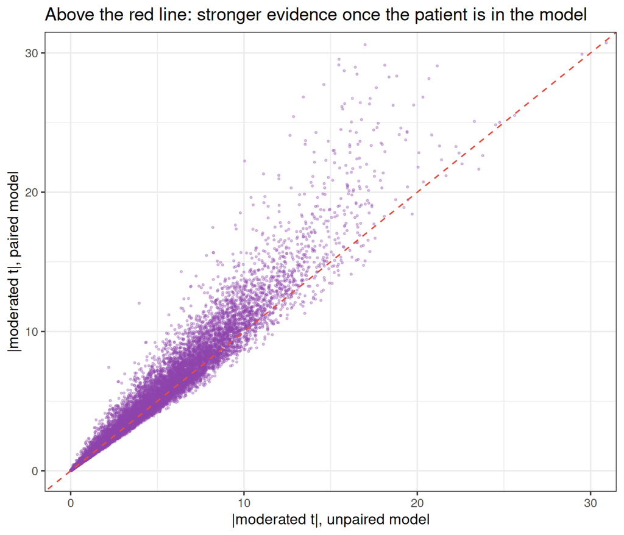

**What pairing buys.** The fold changes are identical in the two models (with one tumor and one normal per child, the average within-child difference equals the difference of the means). What changes is the **noise**: **66%** of genes get a larger |t| in the paired model, because the differences between children are no longer counted as noise, even though each gene has fewer degrees of freedom left. The number of DEGs barely moves here because tumor vs normal kidney is an enormous effect; pairing matters most for **subtle** effects, and it is the correct model whenever samples come in pairs. From now on we use the paired model.

**Another way to pair: `duplicateCorrelation()`.** Instead of one coefficient per patient, limma can treat the patient as a **random block**: `duplicateCorrelation(log_expr, design, block = samples$patient)` estimates how correlated two samples of the same child are, and `lmFit(..., block = samples$patient, correlation = ...)` uses it. This is preferable when only *some* samples are paired (a coefficient for every unpaired patient would waste degrees of freedom); when every sample is paired, as here, the patient coefficients of `~ patient + condition` are the standard choice.

```r
dir.create("results", showWarnings = FALSE)
top_paired %>% rownames_to_column("gene") %>% write_csv("results/limma_tumor_vs_normal_paired.csv")
```

# Part 8 — Testing a Fold-Change Threshold Properly: `treat()`

Above, a gene is a DEG if its adjusted p-value is below 0.05 **and** its estimated |log2FC| exceeds 1. This is very common, but the p-value tests “log2FC = 0”, not “|log2FC| ≤ 1”: a gene whose true change is 1.5-fold, estimated at 2.1-fold by chance, passes both filters. `treat()` tests the right hypothesis directly: **is |log2FC| significantly greater than the threshold?**

```r
fit_treat     <- treat(lmFit(log_expr, design_paired), lfc = log2fc_cutoff, trend = TRUE, robust = TRUE)
results_treat <- decideTests(fit_treat, p.value = padj_cutoff)[, "conditionTumor"]
```

DEGs with the two approaches (paired model).

| method | up | down |
| --- | --- | --- |
| p-value + \|log2FC\| filter | 5482 | 1434 |
| treat(lfc = 1) | 2733 | 705 |

**treat is stricter, and honest.** It keeps only genes for which the data show a change *larger* than two-fold with confidence, so the list is much shorter. Use the post-hoc filter for exploration; use `treat()` when the fold change itself is part of the claim (“more than two-fold up in the tumor”).

# Part 9 — Looking at the Results

## Mean-Difference and Volcano Plots

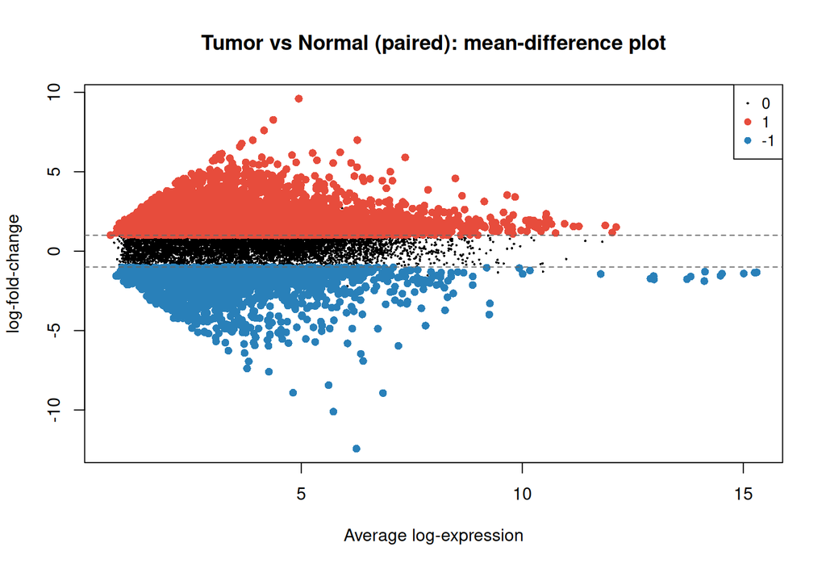

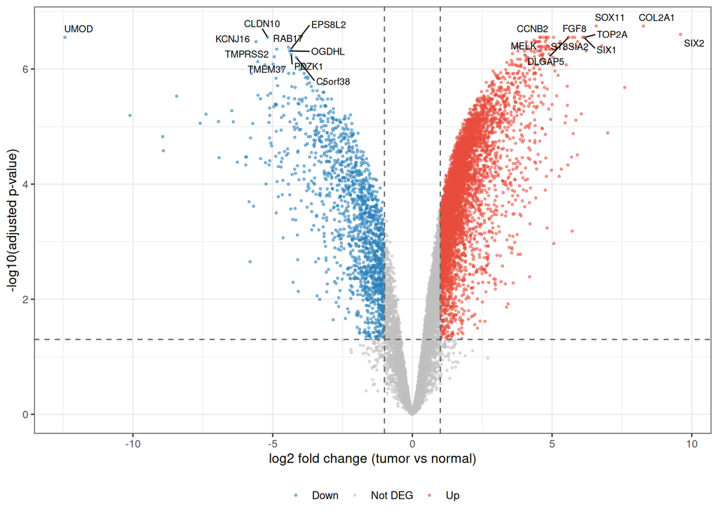

| gene | logFC | AveExpr | t | P.Value | adj.P.Val | B |
| --- | --- | --- | --- | --- | --- | --- |
| SOX11 | 6.58 | 3.61 | 39.85 | 1.73e-11 | 1.79e-07 | 16.27 |
| COL2A1 | 8.27 | 4.37 | 38.03 | 2.63e-11 | 1.79e-07 | 15.97 |
| SIX2 | 9.6 | 4.94 | 35.03 | 5.52e-11 | 2.5e-07 | 15.42 |
| DLGAP5 | 5.59 | 3.74 | 33.27 | 8.77e-11 | 2.81e-07 | 15.06 |
| UMOD | -12.43 | 6.25 | -34.37 | 1.19e-10 | 2.81e-07 | 14.73 |
| SIX1 | 6.14 | 3.2 | 31.55 | 1.41e-10 | 2.81e-07 | 14.68 |
| ST8SIA2 | 5.81 | 3.05 | 30.72 | 1.8e-10 | 2.81e-07 | 14.48 |
| CCNB2 | 4.8 | 4.58 | 30.59 | 1.87e-10 | 2.81e-07 | 14.45 |
| FGF8 | 6.1 | 3.15 | 29.9 | 2.29e-10 | 2.81e-07 | 14.28 |
| TOP2A | 6.18 | 5.26 | 29.54 | 2.55e-10 | 2.81e-07 | 14.19 |

[output cut: 290 more lines]

## A Biological Sanity Check

Known Wilms tumor biology, tumor vs normal.

| gene | logFC | adj.P.Val | expected |
| --- | --- | --- | --- |
| SIX1 | 6.14 | 3.00e-07 | nephron progenitor: up |
| SIX2 | 9.60 | 2.00e-07 | nephron progenitor: up |
| CITED1 | 2.74 | 3.95e-04 | nephron progenitor: up |
| IGF2 | 5.56 | 4.65e-05 | 11p15.5 imprinted: up |
| UMOD | -12.43 | 3.00e-07 | mature tubule: down |
| AQP2 | -8.91 | 2.63e-05 | mature tubule: down |
| SLC22A2 | -3.44 | 1.19e-05 | mature tubule: down |

Wilms tumor arises from **embryonic kidney** tissue that failed to mature: the nephron progenitor genes (`SIX1`, `SIX2`, `CITED1`) and the growth factor `IGF2` (at the 11p15.5 imprinted locus) are up, the mature tubule genes are down. The model measures real biology.

## Gene by Gene, Child by Child

Lines join each child’s normal and tumor sample: the change is consistent **within** children even when baseline levels differ **between** them.

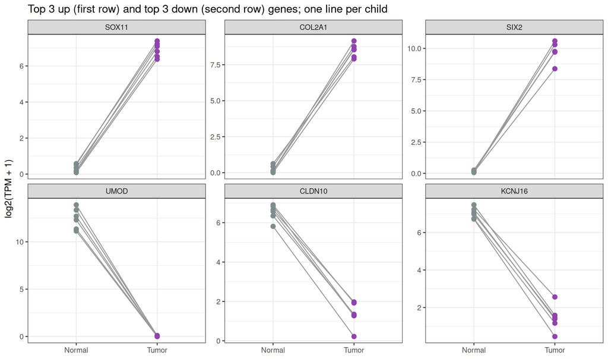

## Heatmap of the Top Genes

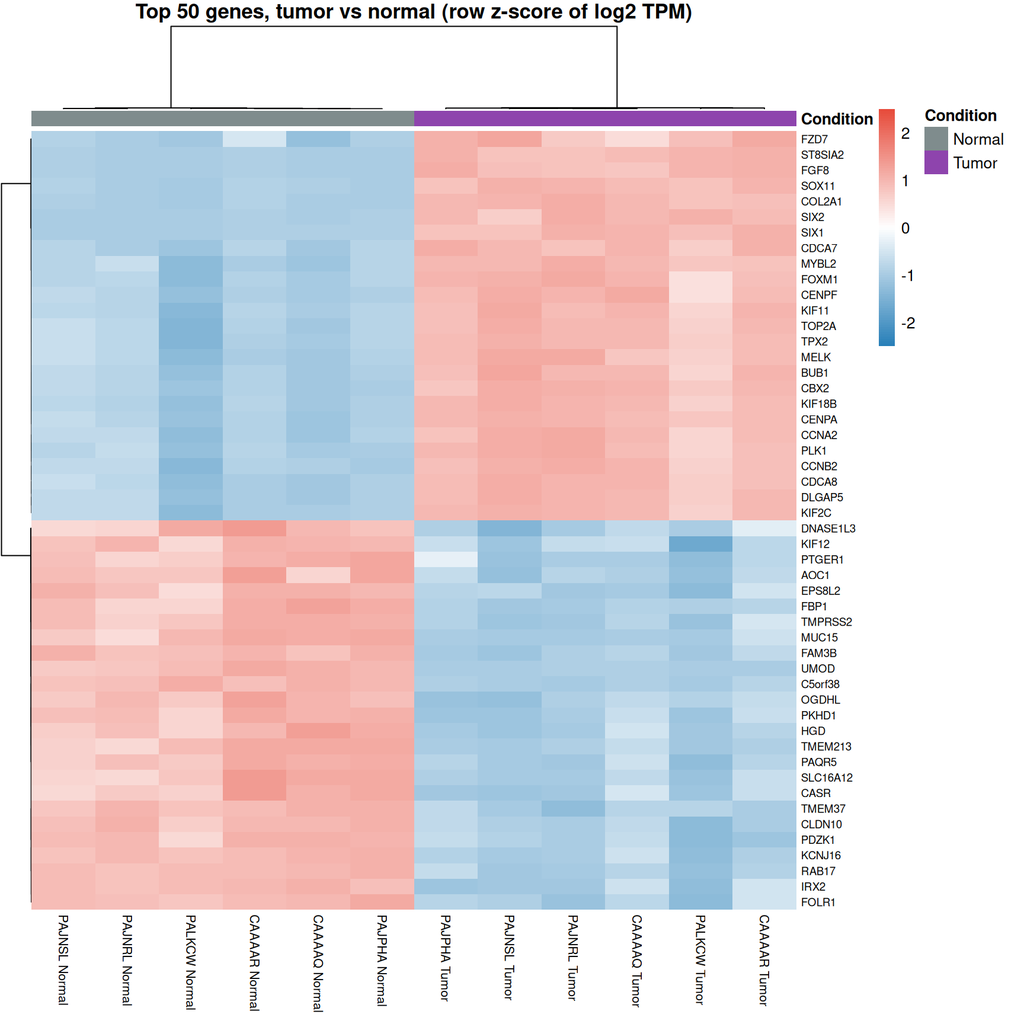

# Summary

- limma fits **one linear model per gene**; the **design matrix** describes the samples and **contrasts** state the questions.
- **Empirical Bayes** (`eBayes`, with `trend = TRUE` for TPM) stabilizes each gene’s variance by borrowing information from all genes: essential with 6 samples per group.
- Adding the **patient** (`~ patient + condition`) turns the analysis into a paired comparison and removes the differences between children from the noise.
- **`treat()`** tests a fold-change threshold properly.
- The full paired results are in `results/limma_tumor_vs_normal_paired.csv` for Module 3.

Generated on 05 novembre 2026 · Francesco Cecere (Senior Bioinformatic Researcher) · AORN Santobono-Pausilipon IRCCS